# KavatkarSeema_ProjectReport

```python
# pip install torch
```

```python
# pip install torchvision
```

```python
# pip install numpy
```

```python
# pip install matplotlib
```

```python
# pip install tqdm
```

# Generating Realistic Faces using GANs

**Author:** Seema Kavatkar  
**Date :** 09th May, 2024  
**Description:** Generating Realistic Faces using GANs

- **Introduction**
- **Data Selection, Preparation and Exploration**
- **Model Implementation and Execution**
- **Results**
- **Conclusion**
- **Future Work**
- **Reference**

### Introduction

The objective of this project is to employ Generative Adversarial Networks (GANs) to generate realistic human faces. Leveraging the `CelebA` dataset, comprising facial images of celebrities, the project aims to create a model that can produce authentic-looking faces indistinguishable from real ones. The value of this project lies in its potential applications in various fields such as entertainment, art, and computer graphics. The results sought include the generation of diverse and high-quality facial images, demonstrating the capabilities of GANs in synthesizing realistic visual content.

### Data Selection, Preparation and Exploration

*Has the data been properly prepared in terms of integration, cleaning, filtering, etc? Have data problems been corrected?* *20%***

The `CelebA` dataset is chosen for this project due to its rich collection of over 200,000 facial images of celebrities, each annotated with various attributes such as hair color, gender, and age. An initial exploration of the dataset will involve:

• Analyzing the distribution of facial attributes to understand the diversity within the dataset.

• Examining sample images to assess the quality and suitability of the data for training GANs.

• Verifying the presence of sufficient variation in facial expressions, poses, and backgrounds to ensure the model's ability to generate diverse faces. Based on this exploration, the suitability of the `CelebA` dataset for the project will be assessed.

```python
# Imports

from __future__ import print_function
%matplotlib inline
import argparse
import os
import random
import torch
import torch.nn as nn
import torch.nn.parallel
import torch.backends.cudnn as cudnn
import torch.optim as optim
import torch.utils.data
import torchvision.datasets as dset
import torchvision.transforms as transforms
import torchvision.utils as vutils
import numpy as np
import matplotlib.pyplot as plt
import matplotlib.animation as animation
from IPython.display import HTML
from tqdm import tqdm
import pandas as pd
from IPython.display import Image

# Set random seed for reproducibility
Seed = 1
random.seed(Seed)
torch.manual_seed(Seed)
```

```
<torch._C.Generator at 0x12c36a190>
```

```python
# Hyper-parameters

# Root directory of where you set your dataset
dataroot = "/Users/seemakavatkar/Documents/Masters in Data Science/Spring 2024/CSCI E 25- Computer Vision/Project/Dataset/"

# Number of samples
num_samples = 1000

# Number of workers for dataloader
workers = 4

# Batch size during training
batch_size = 64

# Spatial size of training images. we will resize All images to this
#   size using a transformer.
image_size = 64

# Number of channels in the training images. For color images this is 3 rbg
nc = 3

# Size of z latent vector (it's the size of the noize vector )
nz = 100

# Size of feature maps in generator
ngf = 64

# Size of feature maps in discriminator
ndf = 64

# Number of training epochs
num_epochs = 10

# Learning rate for optimizers
lr = 0.0002

# Beta1 hyperparam for Adam optimizers
beta1 = 0.5

# Number of GPUs available. Use 0 for CPU mode. & 1 for gpu #mode(like NVIDIA)
ngpu = 0

# Decide which device to run on
device = torch.device("cuda:0" if (torch.cuda.is_available() and ngpu > 0) else "cpu")
```

```python
#
attr_file_path = dataroot + "list_attr_celeba.txt"

# Read the data into a DataFrame
celaba_attr_df = pd.read_csv(attr_file_path, sep='\s+', skiprows=0)

# Display the first few rows of the DataFrame
celaba_attr_df.head()
```

|  | 5_o_Clock_Shadow | Arched_Eyebrows | Attractive | Bags_Under_Eyes | Bald | Bangs | Big_Lips | Big_Nose | Black_Hair | Blond_Hair | ... | Sideburns | Smiling | Straight_Hair | Wavy_Hair | Wearing_Earrings | Wearing_Hat | Wearing_Lipstick | Wearing_Necklace | Wearing_Necktie | Young |
| --- | --- | --- | --- | --- | --- | --- | --- | --- | --- | --- | --- | --- | --- | --- | --- | --- | --- | --- | --- | --- | --- |
| 000001.jpg | -1 | 1 | 1 | -1 | -1 | -1 | -1 | -1 | -1 | -1 | ... | -1 | 1 | 1 | -1 | 1 | -1 | 1 | -1 | -1 | 1 |
| 000002.jpg | -1 | -1 | -1 | 1 | -1 | -1 | -1 | 1 | -1 | -1 | ... | -1 | 1 | -1 | -1 | -1 | -1 | -1 | -1 | -1 | 1 |
| 000003.jpg | -1 | -1 | -1 | -1 | -1 | -1 | 1 | -1 | -1 | -1 | ... | -1 | -1 | -1 | 1 | -1 | -1 | -1 | -1 | -1 | 1 |
| 000004.jpg | -1 | -1 | 1 | -1 | -1 | -1 | -1 | -1 | -1 | -1 | ... | -1 | -1 | 1 | -1 | 1 | -1 | 1 | 1 | -1 | 1 |
| 000005.jpg | -1 | 1 | 1 | -1 | -1 | -1 | 1 | -1 | -1 | -1 | ... | -1 | -1 | -1 | -1 | -1 | -1 | 1 | -1 | -1 | 1 |

5 rows × 40 columns

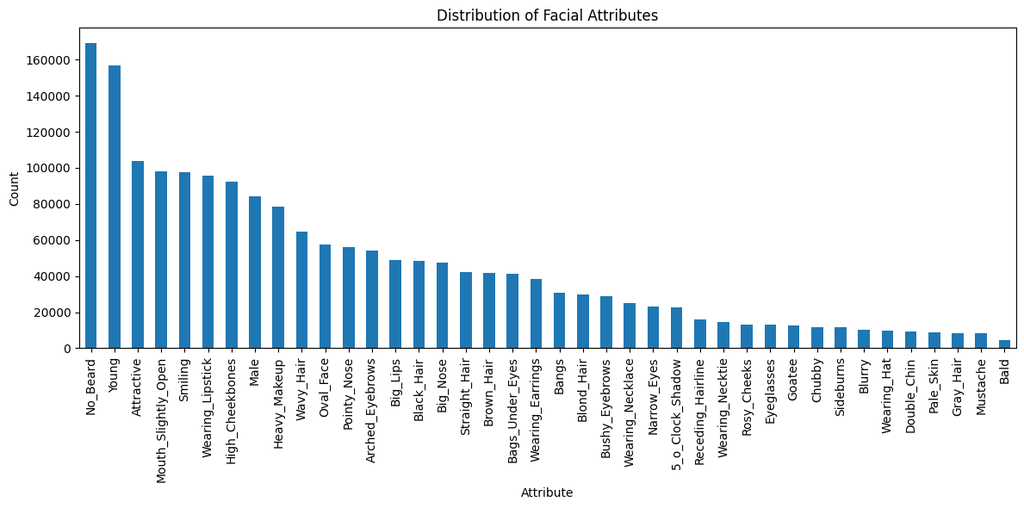

```python
# Initialize an empty dictionary to store attribute counts
attribute_counts = {}

# Iterate over each column and count occurrences of 1
for column in celaba_attr_df.columns:
    if column != 'image_id':  # Exclude 'image_id' column
        attribute_counts[column] = (celaba_attr_df[column] == 1).sum()

# Convert the dictionary to a pandas Series for easier plotting
attribute_counts_series = pd.Series(attribute_counts)

# Sort the Series by counts in descending order
attribute_counts_series = attribute_counts_series.sort_values(ascending=False)

# Create a bar plot using matplotlib
plt.figure(figsize=(12, 6))
attribute_counts_series.plot(kind='bar')
plt.title('Distribution of Facial Attributes')
plt.xlabel('Attribute')
plt.ylabel('Count')
plt.xticks(rotation=90)  # Rotate x-axis labels for better visibility
plt.tight_layout()

# Show the plot
plt.show()
```

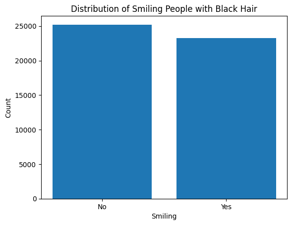

```python
# Filter the DataFrame where Black_Hair column is 1
black_hair_df = celaba_attr_df[celaba_attr_df['Black_Hair'] == 1]

# Count the occurrences of other attributes (you can change the attribute name as needed)
attribute_counts = black_hair_df['Smiling'].value_counts()

# Create a bar plot using matplotlib
plt.bar(['No', 'Yes'], attribute_counts.values)

# Set plot title and labels
plt.title('Distribution of Smiling People with Black Hair')
plt.xlabel('Smiling')
plt.ylabel('Count')

# Show the plot
plt.show()
```

```python
def load_data(dataroot, image_size, batch_size, workers, sample_size, scale_factor):
    # Define the transformations
    transform_list = [
        transforms.Resize(int(image_size * scale_factor)),
        transforms.CenterCrop(image_size),
        transforms.ToTensor(),
        transforms.Normalize((0.5, 0.5, 0.5), (0.5, 0.5, 0.5))
    ]

    # Compose the transformations
    transform = transforms.Compose(transform_list)

    # Load the dataset
    dataset = dset.ImageFolder(root=dataroot, transform=transform)

    # Optionally select a random subset of the dataset
    if sample_size is not None and sample_size < len(dataset):
        dataset = torch.utils.data.Subset(dataset, torch.randperm(len(dataset))[:sample_size])

    # Create the dataloader
    dataloader = torch.utils.data.DataLoader(dataset, batch_size=batch_size,
                                             shuffle=True, num_workers=workers)

    return dataloader

# Set the scale factor for data augmentation
scale_factor = 1.1  # Example scale factor

# Create the DataLoader with sample size= num_samples and data augmentation
dataloader = load_data(dataroot, image_size, batch_size, workers, sample_size=num_samples, scale_factor=scale_factor)
```

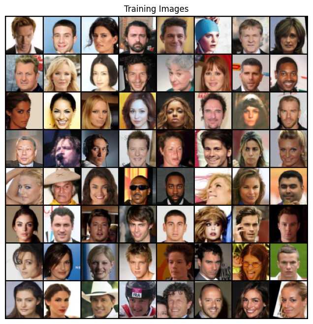

```python
real_batch = next(iter(dataloader))
plt.figure(figsize=(8,8))
plt.axis("off")
plt.title("Training Images")
plt.imshow(np.transpose(vutils.make_grid(real_batch[0].to(device)[:64], padding=2, normalize=True).cpu(),(1,2,0)))
# plt.savefig('real_images_grid.png')
plt.show()
```

```python
# Decide which device to run on
device = torch.device("cuda:0" if (torch.cuda.is_available() and ngpu > 0) else "cpu")
print(device) # Decide which device we want to run on

# To get size of batch size
batch_size = dataloader.batch_size
print("Batch size:", batch_size)

# To get size of dataloader
data_loader_size = len(dataloader)
print("Number of batches in DataLoader:", data_loader_size)

# To get the total number of samples in the DataLoader
total_samples = len(dataloader.dataset)
print("Total number of samples in DataLoader:", total_samples)
```

```
cpu
Batch size: 64
Number of batches in DataLoader: 16
Total number of samples in DataLoader: 1000
```

### Model Implementation and Execution

*Are the modeling methods selected appropriate to the question being addressed? You are expected to consider and compare alternative algorithms and hyperparameter choices to improve your models. Have appropriate steps been taken to improve the models and analysis methods? Examples of model improvement methods include, testing alternative algorithms, testing multiple hyperparameter values for models, and identifying and correcting data problems. A project applying one or two initial models is not acceptable.**30%***

*Is all code used written in a reasonably professional style, including sufficient comments?**10%***

#### What is GAN?

Generative Adversarial Networks(GANs for short) are like artistic duels between two players: the Generator and the Discriminator.

The Generator is like a master forger, creating art (in this case, images) from scratch, often starting with random noise as its canvas. It's constantly trying to improve its technique, making its creations more and more convincing.

The Discriminator, on the other hand, is like a vigilant art critic. It scrutinizes each piece the Generator creates, trying to distinguish between genuine art and mere imitation. It's also constantly refining its judgment, becoming more discerning over time.

As the duel unfolds, the Generator and Discriminator engage in a high-stakes game of cat and mouse. The Generator strives to produce images that fool the Discriminator into thinking they're real, while the Discriminator strives to become increasingly astute at telling real from fake.

Through this adversarial process, both players push each other to greater heights of creativity and skill. The Generator learns to produce images that are indistinguishable from real ones, while the Discriminator becomes an ever more discriminating connoisseur of digital art.

In the end, the GAN produces not just individual images, but an entire gallery of stunningly realistic creations, born from the dynamic interplay between creativity and critique.

This is how the basic `GAN Architecture` looks like:

```python
Image(url="GANArchitecture_Basic.png", width = 1500, height = 900)
```

[figure not shown]

#### Deep Convolutional Generative Adversarial Network (DCGAN for short) Architecture

DCGAN, or Deep Convolutional Generative Adversarial Network, is a type of GAN architecture specifically designed for generating high-quality images. Here's a creative take on explaining DCGAN:

Imagine a team of artists and art critics collaborating to create masterpieces. The artists, known as the Generator, specialize in painting scenes from their wildest imaginations. They use a special technique called deep convolutional layers to bring their visions to life on canvas.

Meanwhile, the art critics, known as the Discriminator, have honed their skills in recognizing true artistry. They carefully examine each painting, scrutinizing the details and textures to distinguish between genuine masterpieces and mere imitations.

As the collaboration unfolds, the Generator and Discriminator engage in a game of artistic one-upmanship. The Generator continually refines its painting technique, striving to create images so lifelike that even the most discerning critic would mistake them for real.

The Discriminator, in turn, becomes an expert at detecting even the subtlest flaws in the artwork. It learns to distinguish between the strokes of a true artist and the clumsy attempts of an amateur.

Through this dynamic interplay between creation and critique, the team produces a gallery of breathtaking images. Each painting is a testament to the power of collaboration between artists and critics, resulting in a collection of digital art that captivates the imagination and blurs the line between reality and illusion.

DCGANs are better than simple GANs because of it :

A) Use Strided Convolutional layers in the discriminator to downsample the images.

B) Use Fractionally–strided convolutional layers to upsample the images.

```python
Image(url="GANArchitecture_Detailed.png", width = 1500, height = 1000)
```

[figure not shown]

```python
def weights_init(m):
    """
    Initialize the weights of convolutional and batch normalization layers using appropriate
    techniques helps to improve the training stability and convergence of neural networks.

    Args:
    - m: The layer to initialize weights for.

    Returns:
    - None

    Description:
    This method initializes the weights of convolutional layers with a normal distribution
    (mean=0, std=0.02) and the weights of batch normalization layers with a normal distribution
    (mean=1, std=0.02). It also initializes the bias of batch normalization layers to 0.
    """
    classname = m.__class__.__name__
    if classname.find('Conv') != -1:
        nn.init.normal_(m.weight.data, 0.0, 0.02)
    elif classname.find('BatchNorm') != -1:
        nn.init.normal_(m.weight.data, 1.0, 0.02)
        nn.init.constant_(m.bias.data, 0)
```

```python
class Generator(nn.Module):
    def __init__(self, ngpu):
        """
        Initialize the Generator module.

        Args:
        - ngpu: Number of GPUs available.

        Returns:
        - None

        Description:
        This method initializes the Generator module with a sequence of transposed convolutional layers.
        It defines the architecture for generating fake images from random noise.

        The architecture consists of several transposed convolutional layers followed by batch normalization
        and ReLU activation functions, except for the last layer, which uses Tanh activation.

        Parameters:
        - ngpu: Number of GPUs available for parallel processing.

        Attributes:
        - ngpu: Number of GPUs available.
        - main: Sequential module containing the layers of the generator network.

        """
        super(Generator, self).__init__()
        self.ngpu = ngpu
        self.main = nn.Sequential(
            # input is Z, going into a convolution
            nn.ConvTranspose2d(in_channels= nz, out_channels = ngf * 8, kernel_size= 4, stride= 1, padding= 0, bias=False),
            nn.BatchNorm2d(num_features= ngf * 8),
            nn.ReLU(True),
            # nn.Dropout(0.5),  # Dropout layer
            # state size. (ngf*8) x 4 x 4
            nn.ConvTranspose2d(in_channels= ngf * 8, out_channels = ngf * 4, kernel_size= 4, stride= 2, padding= 1, bias=False),
            nn.BatchNorm2d(num_features= ngf * 4),
            nn.ReLU(True),
            # nn.Dropout(0.5),  # Dropout layer
            # state size. (ngf*4) x 8 x 8
            nn.ConvTranspose2d(in_channels= ngf * 4, out_channels = ngf * 2, kernel_size= 4, stride= 2, padding= 1, bias=False),
            nn.BatchNorm2d(num_features= ngf * 2),
            nn.ReLU(True),
            # nn.Dropout(0.5),  # Dropout layer
            # state size. (ngf*2) x 16 x 16
            nn.ConvTranspose2d(in_channels= ngf * 2, out_channels = ngf, kernel_size= 4, stride= 2, padding= 1, bias=False),
            nn.BatchNorm2d(num_features= ngf),
            nn.ReLU(True),
            # nn.Dropout(0.5),  # Dropout layer
            # state size. (ngf) x 32 x 32
            nn.ConvTranspose2d(in_channels= ngf, out_channels = nc, kernel_size= 4, stride= 2, padding= 1, bias=False),
            nn.Tanh()
            # state size. (nc) x 64 x 64
        )

    def forward(self, input):
        return self.main(input)
```

```python
# Create the generator
netG = Generator(ngpu).to(device)
# Handle multi-gpu if desired
if (device.type == 'cuda') and (ngpu > 1):
    netG = nn.DataParallel(netG, list(range(ngpu)))
# Apply the weights_init function to initialize the weights of the generator
netG.apply(weights_init)
# Print the generator model
print(netG)
```

```
Generator(
  (main): Sequential(
    (0): ConvTranspose2d(100, 512, kernel_size=(4, 4), stride=(1, 1), bias=False)
    (1): BatchNorm2d(512, eps=1e-05, momentum=0.1, affine=True, track_running_stats=True)
    (2): ReLU(inplace=True)
    (3): ConvTranspose2d(512, 256, kernel_size=(4, 4), stride=(2, 2), padding=(1, 1), bias=False)
    (4): BatchNorm2d(256, eps=1e-05, momentum=0.1, affine=True, track_running_stats=True)
    (5): ReLU(inplace=True)
    (6): ConvTranspose2d(256, 128, kernel_size=(4, 4), stride=(2, 2), padding=(1, 1), bias=False)
    (7): BatchNorm2d(128, eps=1e-05, momentum=0.1, affine=True, track_running_stats=True)
    (8): ReLU(inplace=True)
    (9): ConvTranspose2d(128, 64, kernel_size=(4, 4), stride=(2, 2), padding=(1, 1), bias=False)
    (10): BatchNorm2d(64, eps=1e-05, momentum=0.1, affine=True, track_running_stats=True)
    (11): ReLU(inplace=True)
    (12): ConvTranspose2d(64, 3, kernel_size=(4, 4), stride=(2, 2), padding=(1, 1), bias=False)
    (13): Tanh()
  )
)
```

```python
class Discriminator(nn.Module):
    def __init__(self, ngpu):
        """
        Initialize the Discriminator module.

        Args:
        - ngpu: Number of GPUs available.

        Returns:
        - None

        Description:
        This method initializes the Discriminator module with a sequence of convolutional layers.
        It defines the architecture for distinguishing between real and fake images.

        The architecture consists of several convolutional layers followed by batch normalization,
        leaky ReLU activation functions, and a final sigmoid activation function.

        Parameters:
        - ngpu: Number of GPUs available for parallel processing.

        Attributes:
        - ngpu: Number of GPUs available.
        - main: Sequential module containing the layers of the discriminator network.

        """
        super(Discriminator, self).__init__()
        self.ngpu = ngpu
        self.main = nn.Sequential(
            # input is (nc) x 64 x 64
            nn.Conv2d(in_channels= nc, out_channels= ndf, kernel_size= 4, stride= 2, padding= 1, bias=False),
            nn.LeakyReLU(negative_slope= 0.2, inplace=True),
            # state size. (ndf) x 32 x 32
            nn.Conv2d(in_channels= ndf, out_channels= ndf * 2, kernel_size= 4, stride= 2, padding= 1, bias=False),
            nn.BatchNorm2d(ndf * 2),
            nn.LeakyReLU(negative_slope= 0.2, inplace=True),
            # state size. (ndf*2) x 16 x 16
            nn.Conv2d(in_channels= ndf * 2, out_channels= ndf * 4, kernel_size= 4, stride= 2, padding= 1, bias=False),
            nn.BatchNorm2d(ndf * 4),
            nn.LeakyReLU(negative_slope= 0.2, inplace=True),
            # state size. (ndf*4) x 8 x 8
            nn.Conv2d(in_channels= ndf * 4, out_channels= ndf * 8, kernel_size= 4, stride= 2, padding= 1, bias=False),
            nn.BatchNorm2d(ndf * 8),
            nn.LeakyReLU(negative_slope= 0.2, inplace=True),
            # state size. (ndf*8) x 4 x 4
            nn.Conv2d(in_channels= ndf * 8, out_channels= 1, kernel_size= 4, stride= 1, padding= 0, bias=False),
            nn.Sigmoid()
        )

    def forward(self, input):
        return self.main(input)
```

```python
# Create the Discriminator
netD = Discriminator(ngpu).to(device)

# Handle multi-GPU if desired
if (device.type == 'cuda') and (ngpu > 1):
    netD = nn.DataParallel(netD, list(range(ngpu)))

# Apply the weights_init function to initialize the weights of the discriminator
netD.apply(weights_init)

# Print the discriminator model
print(netD)
```

```
Discriminator(
  (main): Sequential(
    (0): Conv2d(3, 64, kernel_size=(4, 4), stride=(2, 2), padding=(1, 1), bias=False)
    (1): LeakyReLU(negative_slope=0.2, inplace=True)
    (2): Conv2d(64, 128, kernel_size=(4, 4), stride=(2, 2), padding=(1, 1), bias=False)
    (3): BatchNorm2d(128, eps=1e-05, momentum=0.1, affine=True, track_running_stats=True)
    (4): LeakyReLU(negative_slope=0.2, inplace=True)
    (5): Conv2d(128, 256, kernel_size=(4, 4), stride=(2, 2), padding=(1, 1), bias=False)
    (6): BatchNorm2d(256, eps=1e-05, momentum=0.1, affine=True, track_running_stats=True)
    (7): LeakyReLU(negative_slope=0.2, inplace=True)
    (8): Conv2d(256, 512, kernel_size=(4, 4), stride=(2, 2), padding=(1, 1), bias=False)
    (9): BatchNorm2d(512, eps=1e-05, momentum=0.1, affine=True, track_running_stats=True)
    (10): LeakyReLU(negative_slope=0.2, inplace=True)
    (11): Conv2d(512, 1, kernel_size=(4, 4), stride=(1, 1), bias=False)
    (12): Sigmoid()
  )
)
```

```python
# Initialize Binary Cross Entropy (BCE) Loss function
criterion = nn.BCELoss()

# Create batch of latent vectors that we will use to visualize
# the progression of the generator
fixed_noise = torch.randn(64, nz, 1, 1, device=device)

# Establish convention for real and fake labels during training
real_label = 1.
fake_label = 0.

# Setup Adam optimizers for both Generator (G) and Discriminator (D)
optimizerD = optim.Adam(netD.parameters(), lr=lr, betas=(beta1, 0.999))
optimizerG = optim.Adam(netG.parameters(), lr=lr, betas=(beta1, 0.999))
```

```python
import time

start_time = time.strftime("%H:%M:%S", time.localtime())
print("Start time:", start_time)

results_df = pd.DataFrame(columns=['Epoch', 'Iteration', 'Loss_D', 'Loss_G', 'D_x', 'D_G_z1', 'D_G_z2'])
```

```
Start time: 18:25:57
```

```python
# Training Loop
# Lists to keep track of progress
img_list = []
G_losses = []
D_losses = []
iters = 0
print("Starting Training Loop...")
# For each epoch
for epoch in range(num_epochs):
    epoch+=1
    # For each batch in the dataloader
    for i, data in enumerate(dataloader, 0):
        # (1) Update D network: maximize log(D(x)) + log(1 - D(G(z)))
        netD.zero_grad()
        # Format batch
        # print(f"Len: {len(data[0])}, device: {device}")
        real_cpu = data[0].to(device)
        b_size = real_cpu.size(0)
        label = torch.full((b_size,), real_label, dtype=torch.float, device=device)
        # print(f"real_cpu: {type(real_cpu)}, real_cpu: {real_cpu.size()} /n")

        # Forward pass real batch through D
        output = netD(real_cpu).view(-1)
        # print(f"output: {type(output)}, output: {output.size()} /n")
        # print(f"label: {type(label)}, real_cpu: {label.size()} /n")

        # Calculate loss on all-real batch
        errD_real = criterion(output, label)
        # Calculate gradients for D in backward pass
        errD_real.backward()
        D_x = output.mean().item()
        # Train with all-fake batch
        # Generate batch of latent vectors
        noise = torch.randn(b_size, nz, 1, 1, device=device)
        # Generate fake image batch with G
        fake = netG(noise)
        label.fill_(fake_label)
        # Classify all fake batch with D
        output = netD(fake.detach()).view(-1)
        # Calculate D's loss on the all-fake batch
        errD_fake = criterion(output, label)
        # Calculate the gradients for this batch, accumulated (summed) with previous gradients
        errD_fake.backward()
        D_G_z1 = output.mean().item()
        # Compute error of D as sum over the fake and the real batches
        errD = errD_real + errD_fake
        # Update D
        optimizerD.step()

        # (2) Update G network: maximize log(D(G(z)))
        netG.zero_grad()
        label.fill_(real_label)  # fake labels are real for generator cost
        # Since we just updated D, perform another forward pass of all-fake batch through D
        output = netD(fake).view(-1)
        # Calculate G's loss based on this output
        errG = criterion(output, label)
        # Calculate gradients for G
        errG.backward()
        D_G_z2 = output.mean().item()
        # Update G
        optimizerG.step()

        # Output training stats
        if i % 50 == 0:
            results_df.loc[len(results_df)] = [epoch, i, errD.item(), errG.item(), D_x, D_G_z1, D_G_z2]
            print('[%d/%d][%d/%d]\tLoss_D: %.4f\tLoss_G: %.4f\tD(x): %.4f\tD(G(z)): %.4f / %.4f'
                  % (epoch, num_epochs, i, len(dataloader),
                     errD.item(), errG.item(), D_x, D_G_z1, D_G_z2))


        # Save Losses for plotting later
        G_losses.append(errG.item())
        D_losses.append(errD.item())

        # Check how the generator is doing by saving G's output on fixed_noise
        if (iters % 500 == 0) or ((epoch == num_epochs-1) and (i == len(dataloader)-1)):
            with torch.no_grad():
                fake = netG(fixed_noise).detach().cpu()
            img_list.append(vutils.make_grid(fake, padding=2, normalize=True))
        iters += 1

    if epoch % num_epochs == 0:
        torch.save(netG, 'Generator_epoch_{}.pth'.format(epoch))
        print(epoch)
        print('Model saved.')
```

```
Starting Training Loop...
[1/10][0/16]	Loss_D: 2.2830	Loss_G: 6.4068	D(x): 0.6266	D(G(z)): 0.7644 / 0.0029
[2/10][0/16]	Loss_D: 0.0785	Loss_G: 7.5699	D(x): 0.9611	D(G(z)): 0.0318 / 0.0008
[3/10][0/16]	Loss_D: 0.1412	Loss_G: 14.6371	D(x): 0.9219	D(G(z)): 0.0000 / 0.0000
[4/10][0/16]	Loss_D: 0.2324	Loss_G: 6.9683	D(x): 0.9615	D(G(z)): 0.1062 / 0.0025
[5/10][0/16]	Loss_D: 0.2696	Loss_G: 19.0645	D(x): 0.8381	D(G(z)): 0.0000 / 0.0000
[6/10][0/16]	Loss_D: 0.1344	Loss_G: 20.8757	D(x): 0.9066	D(G(z)): 0.0000 / 0.0000
[7/10][0/16]	Loss_D: 0.0838	Loss_G: 5.3240	D(x): 0.9616	D(G(z)): 0.0180 / 0.0180
[8/10][0/16]	Loss_D: 0.1566	Loss_G: 10.4596	D(x): 0.9058	D(G(z)): 0.0062 / 0.0002
[9/10][0/16]	Loss_D: 0.6635	Loss_G: 5.7911	D(x): 0.9669	D(G(z)): 0.3758 / 0.0064
[10/10][0/16]	Loss_D: 0.6435	Loss_G: 6.6120	D(x): 0.9626	D(G(z)): 0.3622 / 0.0035
10
Model saved.
```

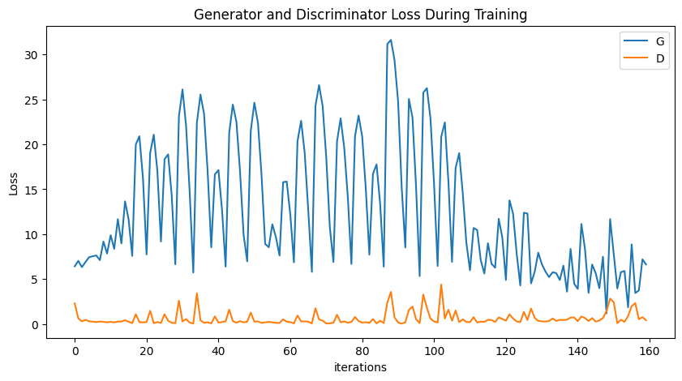

```python
plt.figure(figsize=(10,5))
plt.title("Generator and Discriminator Loss During Training")
plt.plot(G_losses,label="G")
plt.plot(D_losses,label="D")
plt.xlabel("iterations")
plt.ylabel("Loss")
plt.legend()
plt.savefig('generator_discriminator_loss.png')
plt.show()
```

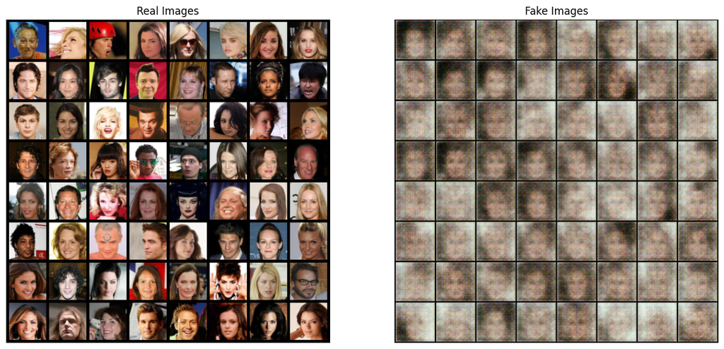

```python
# Grab a batch of real images from the dataloader
real_batch = next(iter(dataloader))
# Plot the real images
plt.figure(figsize=(15,15))
plt.subplot(1,2,1)
plt.axis("off")
plt.title("Real Images")
plt.imshow(np.transpose(vutils.make_grid(real_batch[0].to(device)[:64], padding=5, normalize=True).cpu(),(1,2,0)))
# Plot the fake images from the last epoch
plt.subplot(1,2,2)
plt.axis("off")
plt.title("Fake Images")
plt.imshow(np.transpose(img_list[-1],(1,2,0)))
plt.savefig('fake_images.png')
plt.show()
```

```
MovieWriter ffmpeg unavailable; using Pillow instead.
```

[figure not shown]

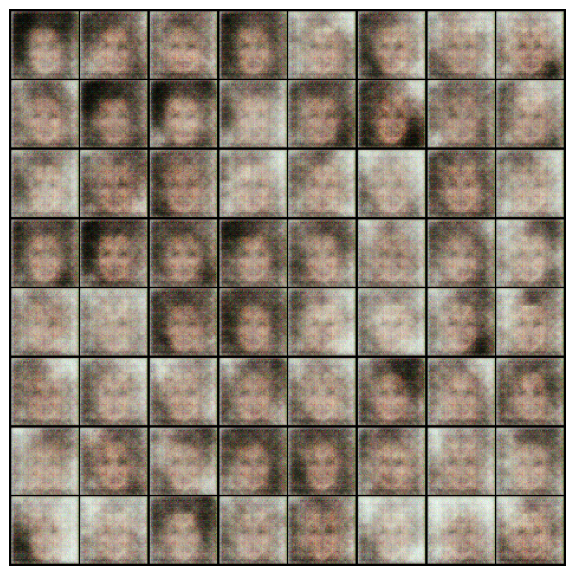

```python
#%%capture
fig = plt.figure(figsize=(8,8))
plt.axis("off")
ims = [[plt.imshow(np.transpose(i,(1,2,0)), animated=True)] for i in img_list]
ani = animation.ArtistAnimation(fig, ims, interval=1000, repeat_delay=1000, blit=True)
# # Save the animation
ani.save('animation.gif', writer='ffmpeg', fps=10)

HTML(ani.to_jshtml())
```

### Results

```python
file_path = 'Experiment.csv'

# Load Excel file into DataFrame with header
experiment_df = pd.read_csv(file_path, header=0)

# Display the DataFrame
experiment_df
```

[output not shown]

9 rows × 24 columns

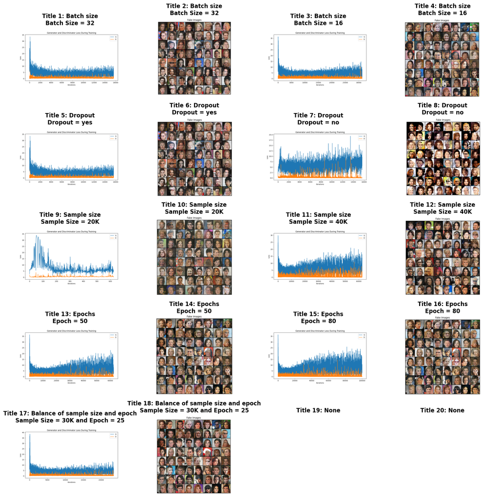

```python
import matplotlib.pyplot as plt
import matplotlib.image as mpimg

# Data for the graph
titles = [
    "Batch size\nBatch Size = 32",
    "Batch size\nBatch Size = 32",
    "Batch size\nBatch Size = 16",
    "Batch size\nBatch Size = 16",
    "Dropout\nDropout = yes",
    "Dropout\nDropout = yes",
    "Dropout\nDropout = no",
    "Dropout\nDropout = no",
    "Sample size\nSample Size = 20K",
    "Sample size\nSample Size = 20K",
    "Sample size\nSample Size = 40K",
    "Sample size\nSample Size = 40K",
    "Epochs\nEpoch = 50",
    "Epochs\nEpoch = 50",
    "Epochs\nEpoch = 80",
    "Epochs\nEpoch = 80",
    "Balance of sample size and epoch\nSample Size = 30K and Epoch = 25",
    "Balance of sample size and epoch\nSample Size = 30K and Epoch = 25",
    "None",
    "None"
]

# Plotting the graph
fig, axs = plt.subplots(5, 4, figsize=(15, 15))

# Setting titles for each block and loading images
for i, ax in enumerate(axs.flat):
    if i == 20:
        break

    ax.set_title(f"Title {i+1}: {titles[i]}", fontsize=12, fontweight='bold')
    ax.axis('off')  # Hide axis

    if i % 2 == 0:
        img_path = f'Images/generator_discriminator_loss_{i//2 + 1}.png'
    else:
        img_path = f'Images/fake_images_{i//2 + 1}.png'

    img = mpimg.imread(img_path)
    ax.imshow(img)
    ax.axis('off')  # Hide axis


plt.tight_layout()
plt.show()
```

Note: Due to resourse extensive experiments could try only few variation and the results captured during these experiments are also uploaded. There are couple of places these are missing due to technical glitch

### Conclusion

The effectiveness of a trained GAN can be assessed based on the quality of the generated samples, the stability of the training process, convergence behavior, and performance on evaluation metrics. Interpretation of these factors can guide further iterations of model development and training to improve the GAN's performance.

Here are the various experiment methods tried to improve the performance of GANs

**1. Adjusting Training strategies or Empirical experimentation**

- Adjusting number of epoch and well sample size.

**2. Regularization Techniques:**

- Apply dropout or other forms of regularization to prevent mode collapse and encourage exploration of the data distribution.

**3.Normalization Methods:**

- Applying Normalization Layers in the nextwork.

**4. Data Augmentation**

**5. Hyperparameter Tuning**

Upon visually inspecting the loss values plotted against the number of iterations, it appears that the model has not yet reached convergence. Typically, when a model converges, both the generator and discriminator losses stabilize or decrease gradually over time, indicating a stable solution. However, in our case, although the discriminator's loss seems relatively stable, the generator's loss fluctuates significantly, suggesting instability. It appears that the generator network struggles to stabilize during the experiment we conducted.

Having said that, there is a variation in the data generated, which indicates that the distribution of the dataset is appropriate and has helped the generator to learn the variation. However, the images generated by the generator do not exhibit high-quality samples resembling the real data. Convergence is often evidenced by generated images that become increasingly realistic and coherent over time, with fewer artifacts and distortions. However, as the generated images display blurriness, lack of detail, or fail to capture important features of the real data, it indicates that the model has not converged effectively. Therefore, based on the visual inspection of the generated images, we can conclude that the model is not converging and needs some additional treatment.

### Future Work

1. Try some other improvement techniques
2. Comparing the outcome of Generative Adversarial Networks (GANs) and Denoising Diffusion Implicit Models by keeping possible hyper-parameters same.
3. Try running the network with full dataset which is 200K+ images. It is going to be time and resource consuming but the end results would be interesting.

### References

Here are the additional reference other than class notes:

[1] https://proceedings.neurips.cc/paper_files/paper/2014/file/5ca3e9b122f61f8f06494c97b1afccf3-Paper.pdf

[2] https://github.com/jpowie01/DCGAN_CelebA

[3] https://www.kaggle.com/datasets/jessicali9530/celeba-dataset

[4] https://gsurma.medium.com/face-generator-generating-artificial-faces-with-machine-learning-9e8c3d6c1ead

[5] https://medium.com/aiguys/implementing-deep-convolutional-generative-adversarial-network-dcgan-using-celeba-dataset-b06e54bb0b44

[6] https://medium.com/the-generator/a-basic-variational-autoencoder-in-pytorch-trained-on-the-celeba-dataset-f29c75316b26

[7] https://towardsdatascience.com/how-to-train-stylegan-to-generate-realistic-faces-d4afca48e705

[8] https://mmlab.ie.cuhk.edu.hk/projects/CelebA.html

[9] https://machinelearningmastery.com/loss-and-loss-functions-for-training-deep-learning-neural-networks/